# Estudis d'Informàtica, Multimedia i Telecomunicacions

# Mineria de dades: PAC1

Març 2020

# 1 Introducció

## 1.1 Presentació

Aquesta prova d’avaluació continuada cobreix els mòduls 1, 2 i 8 del programa de l’assignatura.

## 1.2 Competències

Les competències que es treballen en aquesta prova són:

- Ús i aplicació de les TIC en l’àmbit acadèmic i professional
- Capacitat per a innovar i generar noves idees.
- Capacitat per a avaluar solucions tecnològiques i elaborar propostes de projectes tenint en compte els recursos, les alternatives disponibles i les condicions de mercat.
- Conèixer les tecnologies de comunicacions actuals i emergents, així com saber-les aplicar convenientment per a dissenyar i desenvolupar solucions basades en sistemes i tecnologies de la informació.
- Aplicació de les tècniques específiques d’enginyeria del programari en les diferents etapes del cicle de vida d’un projecte.
- Capacitat per a aplicar les tècniques específiques de tractament, emmagatzematge i administració de dades.
- Capacitat per a proposar i avaluar diferents alternatives tecnològiques per a resoldre un problema concret.
- Capacitat d’utilitzar un llenguatge de programació.
- Capacitat per a desenvolupar en una eina IDE.
- Capacitat de plantejar un projecte de mineria de dades.

## 1.3 Objectius

- Assimilar correctament els mòduls 1 i 2.
- Què és i què no és MD.
- Cicle de vida dels projectes de MD.
- Diferents tipologies de MD.
- Conèixer les tècniques pròpies d’una fase de preparació de dades i objectius a assolir.

## 1.4 Descripció de la PAC a realitzar

La prova està estructurada en 1 exercici teòric/pràctic i 1 exercici pràctic que demana que es desenvolupi la fase de preparació amb un joc de dades. S’han de respondre’s tots els exercicis per a poder superar la PAC.

## 1.5 Recursos

Per a realitzar aquesta pràctica recomanem com a punt de partida la lectura dels següents documents:

- Mòdul 1, 2 i 8 del material didàctic.
- RStudio Cheat Sheet: Disponible a l’aula Laboratori de Mineria de dades.
- R Base Cheat Sheet: Disponible a l’aula Laboratori de Mineria de dades.

## 1.6 Format i data de lliurament

El format de lliurament desitjat és: usernameestudiant-PAC1.html i rmd. Data de Lliurament: 01/04/2020. S’ha de lliurar la PAC en la bústia de lliuraments de l’aula.

## 1.7 Nota: Propietat intel·lectual

> Sovint és inevitable, en produir una obra multimèdia, fer ús de recursos creats per terceres persones. És per tant comprensible fer-ho en el marc d’una pràctica dels estudis d’Informàtica, Multimèdia i Telecomunicació de la UOC, sempre que això es documenti clarament i no suposi plagi en la pràctica.

> Per tant, en presentar una pràctica que faci ús de recursos aliens, s’ha de presentar juntament amb ella un document en què es detallin tots ells, especificant el nom de cada recurs, el seu autor, el lloc on es va obtenir i el seu estatus legal: si l’obra està protegida pel copyright o s’acull a alguna altra llicència d’ús (Creative Commons, llicència GNU, GPL …). L’estudiant haurà d’assegurar-se que la llicència no impedeix específicament el seu ús en el marc de la pràctica. En cas de no trobar la informació corresponent haurà d’assumir que l’obra està protegida per copyright.

> Haureu, a més, adjuntar els fitxers originals quan les obres utilitzades siguin digitals, i el seu codi font si correspon.

# 2 Enunciat

Com a mostra, treballarem amb el joc de dades “Titànic” que recull dades sobre el famós creuer i sobre el que és fàcil fer tasques de classificació predictiva sobre la variable “Survived”.

De moment deixarem per a les següents pràctiques l’estudi d’algorismes predictius i ens centrarem ara com ara en l’estudi de les variables d’un joc de dades, és a dir, farem un treball descriptiu d’aquest.

Les activitats que durem a terme en aquesta pràctica solen emmarcar-se en les fases inicials d’un projecte de mineria de dades i consisteixen en la selecció de característiques o variables, la preparació del joc de dades per a posteriorment ser consumit per un algorisme i intentar extreure el màxim coneixement possible de les dades. Són un subconjunt de tasques mínimes i d’exemple. Podem incloure moltes més i molt més profundes, com hem vist als material docent.

Les tècniques que treballarem com exemple són les següents:

1. Normalització
2. Discretització
3. Gestió de valors nuls
4. Estudi de correlacions
5. Reducció de la dimensionat
6. Anàlisi visual del joc de dades

# 3 Exemple d’estudi visual amb el joc de dades Titànic

## 3.1 Processos de neteja del joc de dades

Primer contacte amb el joc de dades, visualitzem la seva estructura.

```r
# Carreguem els paquets R que utilitzarem
library(ggplot2)
library(dplyr)

# Carreguem el fitxer de dades
totalData <- read.csv('titanic.csv',stringsAsFactors = FALSE)
filas=dim(totalData)[1]


# Verifiquem l'estructura del joc de dades
str(totalData)
```

```
## 'data.frame':    2207 obs. of  11 variables:
##  $ name    : chr  "Abbing, Mr. Anthony" "Abbott, Mr. Eugene Joseph" "Abbott, Mr. Rossmore Edward" "Abbott, Mrs. Rhoda Mary 'Rosa'" ...
##  $ gender  : chr  "male" "male" "male" "female" ...
##  $ age     : num  42 13 16 39 16 25 30 28 27 20 ...
##  $ class   : chr  "3rd" "3rd" "3rd" "3rd" ...
##  $ embarked: chr  "S" "S" "S" "S" ...
##  $ country : chr  "United States" "United States" "United States" "England" ...
##  $ ticketno: int  5547 2673 2673 2673 348125 348122 3381 3381 2699 3101284 ...
##  $ fare    : num  7.11 20.05 20.05 20.05 7.13 ...
##  $ sibsp   : int  0 0 1 1 0 0 1 1 0 0 ...
##  $ parch   : int  0 2 1 1 0 0 0 0 0 0 ...
##  $ survived: chr  "no" "no" "no" "yes" ...
```

Descripció de les variables contingudes al fitxer:

name a string with the name of the passenger.

gender a factor with levels male and female.

age a numeric value with the persons age on the day of the sinking. The age of babies (under 12 months) is given as a fraction of one year (1/month).

class a factor specifying the class for passengers or the type of service aboard for crew members.

embarked a factor with the persons place of of embarkment.

country a factor with the persons home country.

ticketno a numeric value specifying the persons ticket number (NA for crew members).

fare a numeric value with the ticket price (NA for crew members, musicians and employees of the shipyard company).

sibsp an ordered factor specifying the number if siblings/spouses aboard; adopted from Vanderbild data set.

parch an ordered factor specifying the number of parents/children aboard; adopted from Vanderbild data set.

survived a factor with two levels (no and yes) specifying whether the person has survived the sinking.

Treiem estadístiques bàsiques i despres treballem els atributs amb valors buits.

```r
#Estadístiques bàsiques
summary(totalData)
```

```
##      name              gender               age             class
##  Length:2207        Length:2207        Min.   : 0.1667   Length:2207
##  Class :character   Class :character   1st Qu.:22.0000   Class :character
##  Mode  :character   Mode  :character   Median :29.0000   Mode  :character
##                                        Mean   :30.4367
##                                        3rd Qu.:38.0000
##                                        Max.   :74.0000
##                                        NA's   :2
##    embarked           country             ticketno            fare
##  Length:2207        Length:2207        Min.   :      2   Min.   :  3.030
##  Class :character   Class :character   1st Qu.:  14262   1st Qu.:  7.181
##  Mode  :character   Mode  :character   Median : 111427   Median : 14.090
##                                        Mean   : 284216   Mean   : 33.405
##                                        3rd Qu.: 347077   3rd Qu.: 31.061
##                                        Max.   :3101317   Max.   :512.061
##                                        NA's   :891       NA's   :916
##      sibsp            parch          survived
##  Min.   :0.0000   Min.   :0.0000   Length:2207
##  1st Qu.:0.0000   1st Qu.:0.0000   Class :character
##  Median :0.0000   Median :0.0000   Mode  :character
##  Mean   :0.4996   Mean   :0.3856
##  3rd Qu.:1.0000   3rd Qu.:0.0000
##  Max.   :8.0000   Max.   :9.0000
##  NA's   :900      NA's   :900
```

```r
# Estadístiques de valors buits
colSums(is.na(totalData))
```

```
##     name   gender      age    class embarked  country ticketno     fare
##        0        0        2        0        0       81      891      916
##    sibsp    parch survived
##      900      900        0
```

```r
colSums(totalData=="")
```

```
##     name   gender      age    class embarked  country ticketno     fare
##        0        0       NA        0        0       NA       NA       NA
##    sibsp    parch survived
##       NA       NA        0
```

```r
# Prenem valor "Desconegut" per als valors buits de la variable "country"
totalData$country[totalData$country==""]="Desconegut"

# Prenem la mitjana per a valors buits de la variable "age"
totalData$age[is.na(totalData$age)] <- mean(totalData$age,na.rm=T)
```

Discretitzem quan té sentit i en funció de cada variable.

```r
# Per a quines variables tindria sentit un procés de discretizació?
apply(totalData,2, function(x) length(unique(x)))
```

```
##     name   gender      age    class embarked  country ticketno     fare
##     2202        2       80        7        4       49      925      277
##    sibsp    parch survived
##        8        9        2
```

```r
# Discretitzem les variables amb poques classes
cols<-c("survived","class","gender","embarked")
for (i in cols){
  totalData[,i] <- as.factor(totalData[,i])
}

# Després dels canvis, analitzem la nova estructura del joc de dades
str(totalData)
```

```
## 'data.frame':    2207 obs. of  11 variables:
##  $ name    : chr  "Abbing, Mr. Anthony" "Abbott, Mr. Eugene Joseph" "Abbott, Mr. Rossmore Edward" "Abbott, Mrs. Rhoda Mary 'Rosa'" ...
##  $ gender  : Factor w/ 2 levels "female","male": 2 2 2 1 1 2 2 1 2 2 ...
##  $ age     : num  42 13 16 39 16 25 30 28 27 20 ...
##  $ class   : Factor w/ 7 levels "1st","2nd","3rd",..: 3 3 3 3 3 3 2 2 3 3 ...
##  $ embarked: Factor w/ 4 levels "B","C","Q","S": 4 4 4 4 4 4 2 2 2 4 ...
##  $ country : chr  "United States" "United States" "United States" "England" ...
##  $ ticketno: int  5547 2673 2673 2673 348125 348122 3381 3381 2699 3101284 ...
##  $ fare    : num  7.11 20.05 20.05 20.05 7.13 ...
##  $ sibsp   : int  0 0 1 1 0 0 1 1 0 0 ...
##  $ parch   : int  0 2 1 1 0 0 0 0 0 0 ...
##  $ survived: Factor w/ 2 levels "no","yes": 1 1 1 2 2 2 1 2 2 2 ...
```

## 3.2 Processos d’anàlisis del joc de dades

Ens proposem analitzar les relacions entre les diferents variables del joc de dades per veure si es relacionen i com.

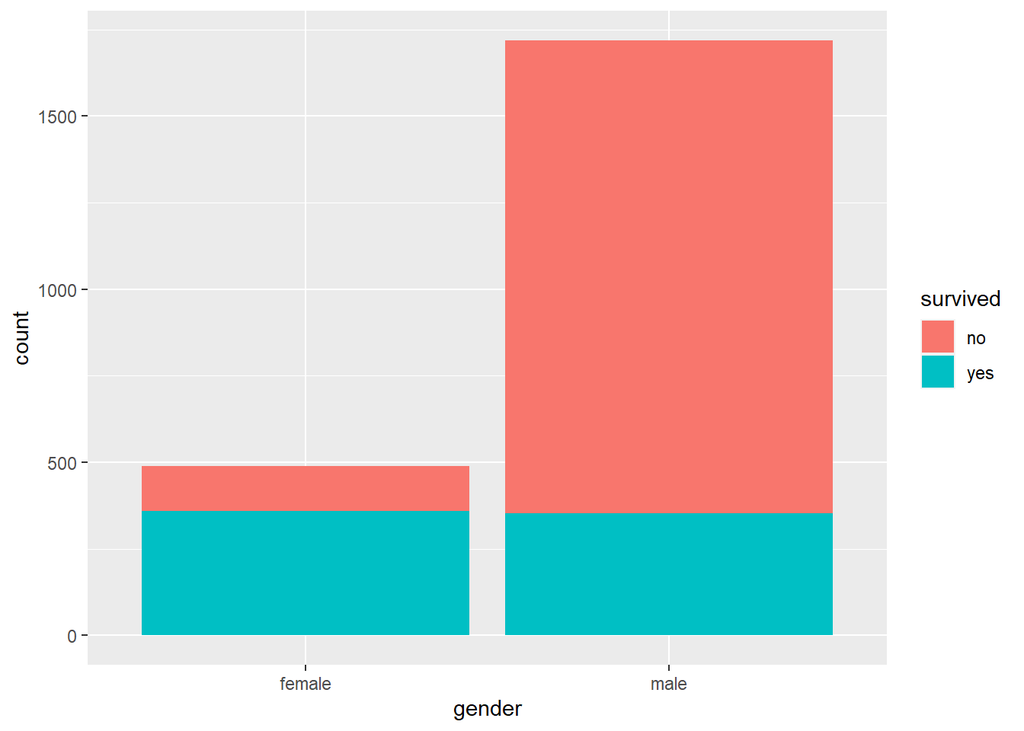

```r
# Visualitzem la relació entre les variables "gender" i "survived":
ggplot(data=totalData[1:filas,],aes(x=gender,fill=survived))+geom_bar()
```

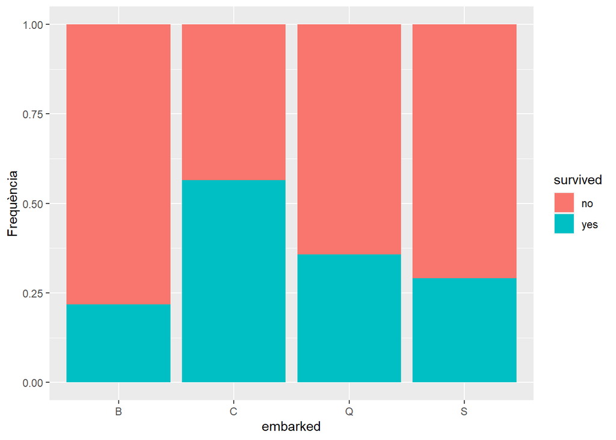

```r
# Un altre punt de vista. Survived com a funció de Embarked:
ggplot(data = totalData[1:filas,],aes(x=embarked,fill=survived))+geom_bar(position="fill")+ylab("Frequència")
```

A la primer gràfica podem observar fàcilment la quantitat de dones que viatjaven respecte homes i observar els que no varem sobreviure. Numèricament el nombre d’homes i dones supervivents és similar.

A la segona gràfica de forma percentual observem els ports d’embarcament i els percentatges de supervivència en funció del port. Es podria treballar el port C (Cherbourg) per veure d’explicar la diferència a les dades. Poder percentualment van embarcar més dones o nens… O gent de primera classe?

Obtenim ara una matriu de percentatges de freqüència. Veiem, per exemple que la probabilitat de sobreviure si es va embarcar en “C” és d’un 56.45%

```r
t<-table(totalData[1:filas,]$embarked,totalData[1:filas,]$survived)
for (i in 1:dim(t)[1]){
    t[i,]<-t[i,]/sum(t[i,])*100
}
t
```

```
##
##           no      yes
##   B 78.17259 21.82741
##   C 43.54244 56.45756
##   Q 64.22764 35.77236
##   S 70.85396 29.14604
```

Vegem ara com en un mateix gràfic de freqüències podem treballar amb 3 variables: Embarked, Survived i class.

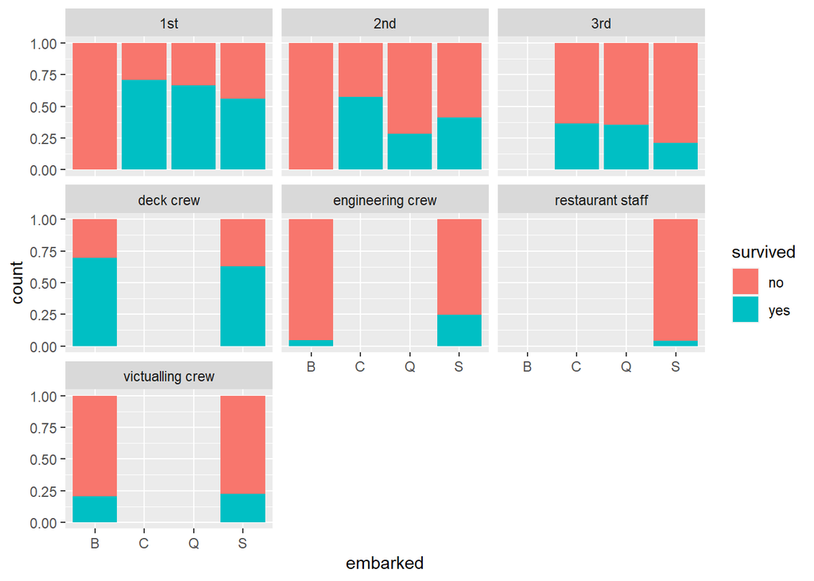

```r
# Mostrem el gràfic d'embarcats per Pclass:
ggplot(data = totalData[1:filas,],aes(x=embarked,fill=survived))+geom_bar(position="fill")+facet_wrap(~class)
```

Aquí ja podem extreure molta informació. Com a proposta de millora es podria fer un gràfic similar treballant només la classe. Caldria unificar tota la tripulació a una única categoria.

Comparem ara dos gràfics de freqüències: Survived-SibSp i Survived-Parch

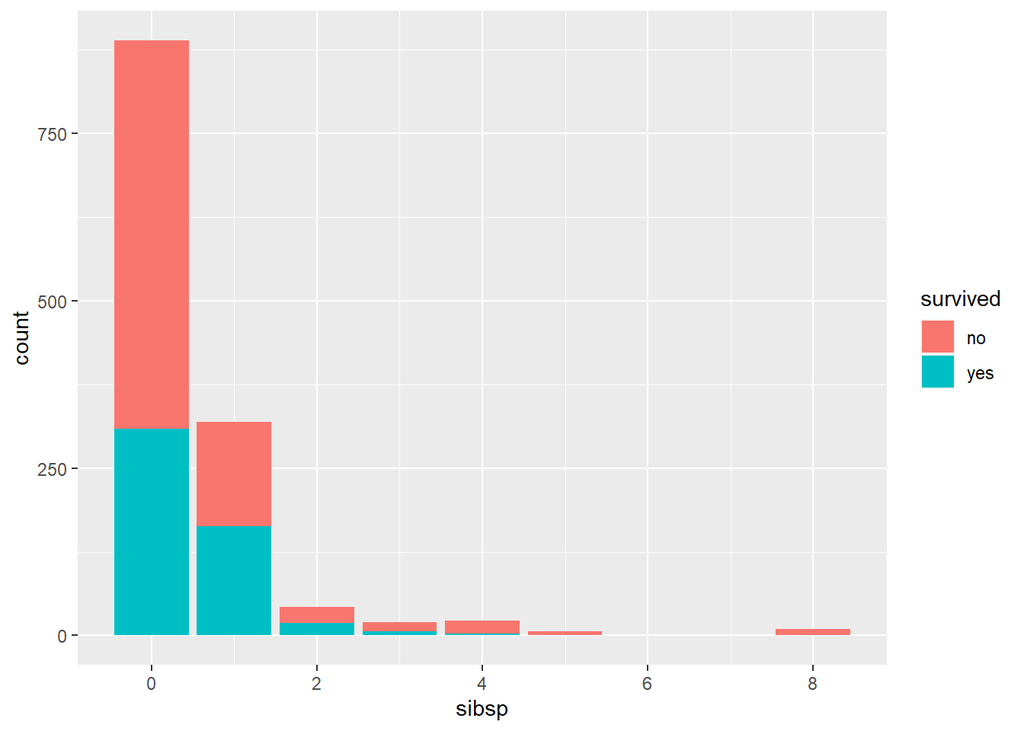

```r
# Survival com a funció de SibSp i Parch
ggplot(data = totalData[1:filas,],aes(x=sibsp,fill=survived))+geom_bar()
```

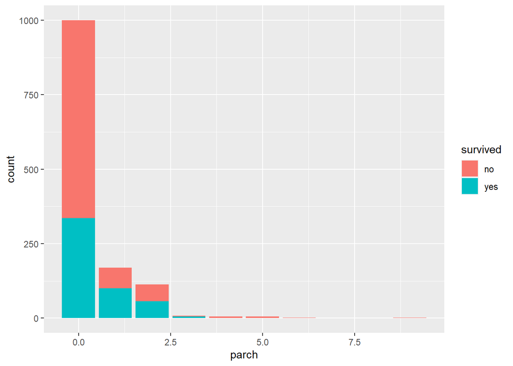

```r
ggplot(data = totalData[1:filas,],aes(x=parch,fill=survived))+geom_bar()
```

```r
# Veiem com la forma d'aquests dos gràfics és similar. Aquest fet ens pot indicar presència de correlacions altes. Fet previsible en funció de la descripció de les variables.
```

Vegem un exemple de construcció d’una variable nova: Grandària de família

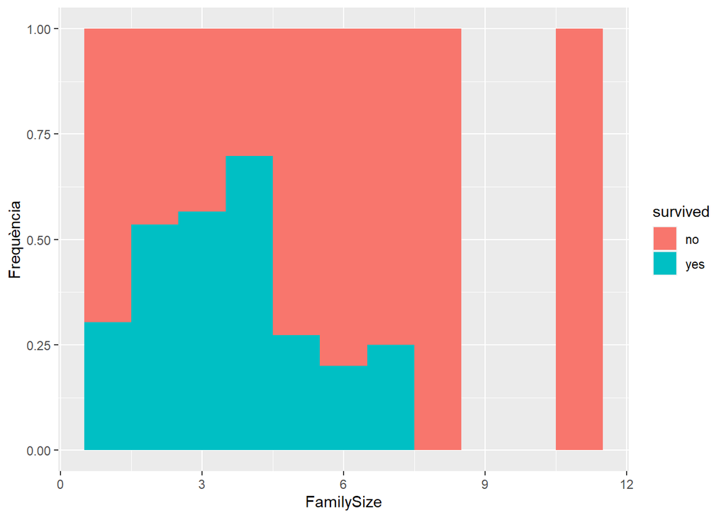

```r
# Construïm un atribut nou: family size..
totalData$FamilySize <- totalData$sibsp + totalData$parch +1;
totalData1<-totalData[1:filas,]
ggplot(data = totalData1[!is.na(totalData[1:filas,]$FamilySize),],aes(x=FamilySize,fill=survived))+geom_histogram(binwidth =1,position="fill")+ylab("Frequència")
```

```r
# Observamos como las familias de 2 a 4 miembros tienen más del 50% de posibilidades de supervivencia.
```

Vegem ara dos gràfics que ens compara els atributs Age i Survived. Observem com el paràmetre position=“fill” ens dóna la proporció acumulada d’un atribut dins d’un altre

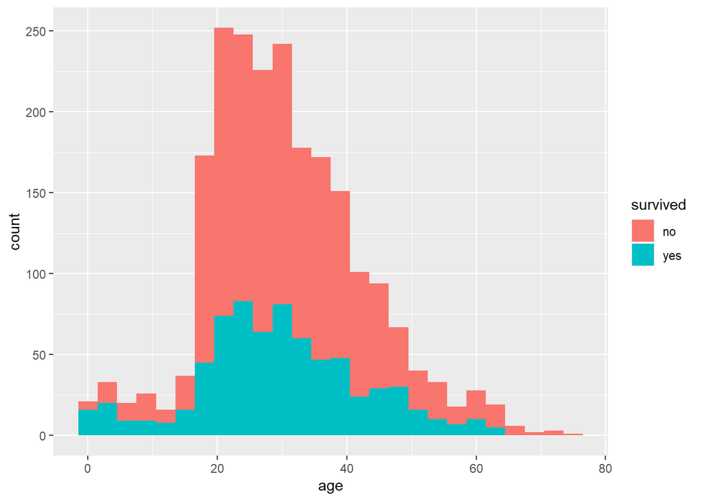

```r
# Survival com a funció de age:
ggplot(data = totalData1[!(is.na(totalData[1:filas,]$age)),],aes(x=age,fill=survived))+geom_histogram(binwidth =3)
```

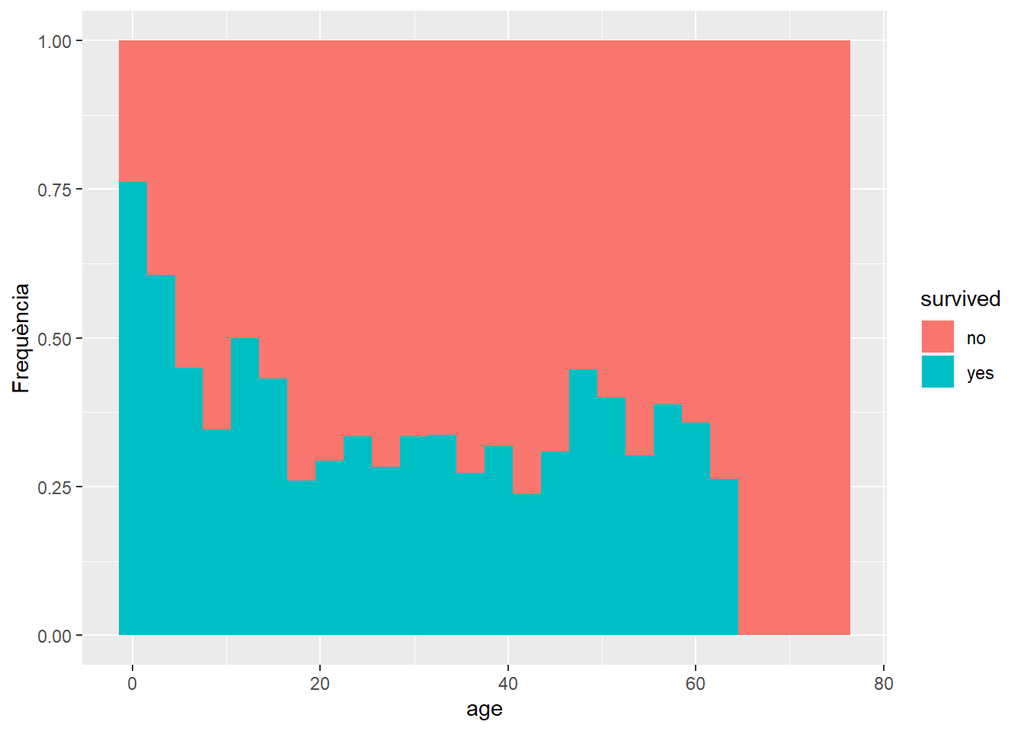

```r
ggplot(data = totalData1[!is.na(totalData[1:filas,]$age),],aes(x=age,fill=survived))+geom_histogram(binwidth = 3,position="fill")+ylab("Frequència")
```